# Repàs dels conceptes bàsics d’Estadística

Antoni Miñarro (aminarro@ub.edu)

16 setembre, 2024

# 1 Subdivisió de l’Estadística

- TEORIA DE LES PROBABILITATS
  - Estudi dels models probabilístics dels fenòmens aleatoris
  - Tècniques deductives
- INFERÈNCIA ESTADISTICA
  - A partir d’un conjunt de resultats particulars (MOSTRA) tracta de reconstruir el model probabilístic subjacent
  - Tècniques inductives

# 2 Idees principals

- Darrera de tot esdeveniment aleatori hi ha un model probabilístic que controla les freqüències en que es produeixen els diferents resultats possibles.
- La probabilitat és una mesura de les freqüències teòriques d’aquests resultats.
- El model probabilístic s’expressa mitjançant les funcions de distribució i densitat referides a variables aleatòries construïdes sobre l’experiment. (Distribució de les variables).
- Existeixen certes famílies de distribucions d’especial rellevància.
- Entre les discretes destaquem la Binomial i la Poisson.
- Entre les continues la més important és la Normal.
- El teorema central del límit justifica aproximacions de diverses distribucions a la Normal i l’abundància de variables aleatòries amb distribució normal en les ciències experimentals.

# 3 Inferència Estadística

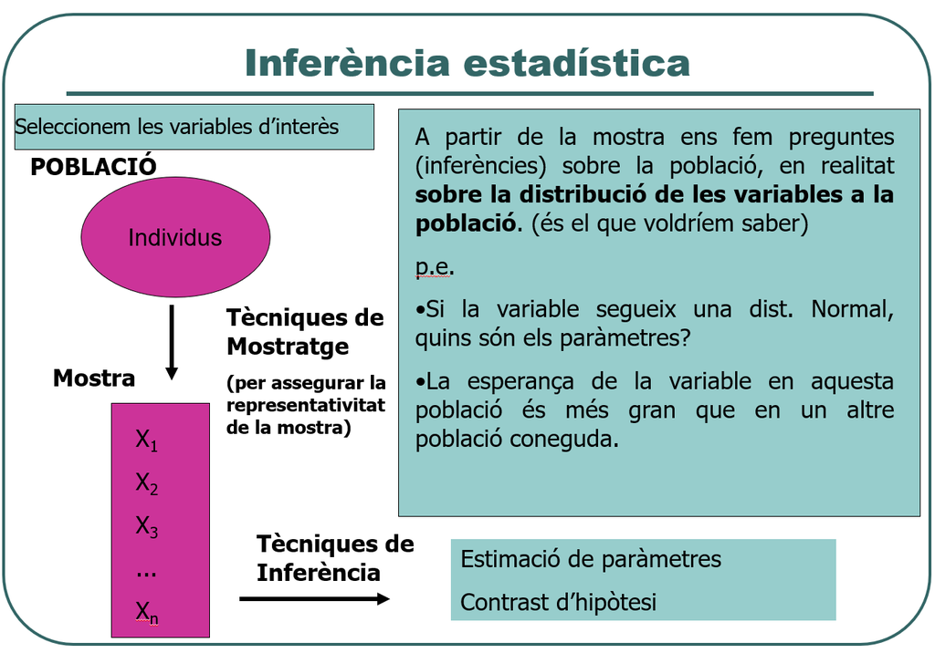

# 4 Estimació de paràmetres

**Estimació de paràmetres**: Suposat un cert model probabilístic (una distribució) quins són els paràmetres que millor s’adapten a la mostra.

- Tipus d’estimació
  - Estimació puntual
  - Estimació per intervals de confiança

## 4.1 Exemple I: Estimació de paràmetres

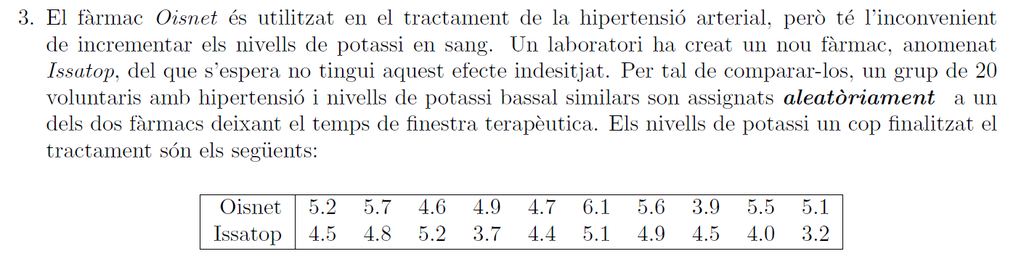

- Quin és l’interval de confiança al 95% del nivell mig de potassi de la població de malalts tractats amb Issatop

Com Issatop és un nou fàrmac, anem a estudiar una mica al seu comportament respecte els nivells de potassi, tot suposant que els nivells de potassi en sang segueix una distribució normal $N(\mu,\sigma)$

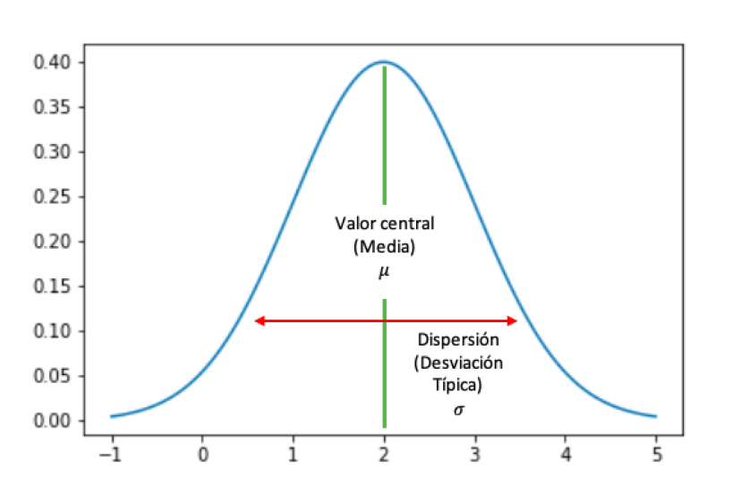

```r
dades<-read.table('farmac.csv',header=T,sep=';',dec=',',stringsAsFactors = TRUE)
```

```r
summary(dades)
```

```
##      Oisnet         Issatop
##  Min.   :3.900   Min.   :3.200
##  1st Qu.:4.750   1st Qu.:4.100
##  Median :5.150   Median :4.500
##  Mean   :5.130   Mean   :4.430
##  3rd Qu.:5.575   3rd Qu.:4.875
##  Max.   :6.100   Max.   :5.200
```

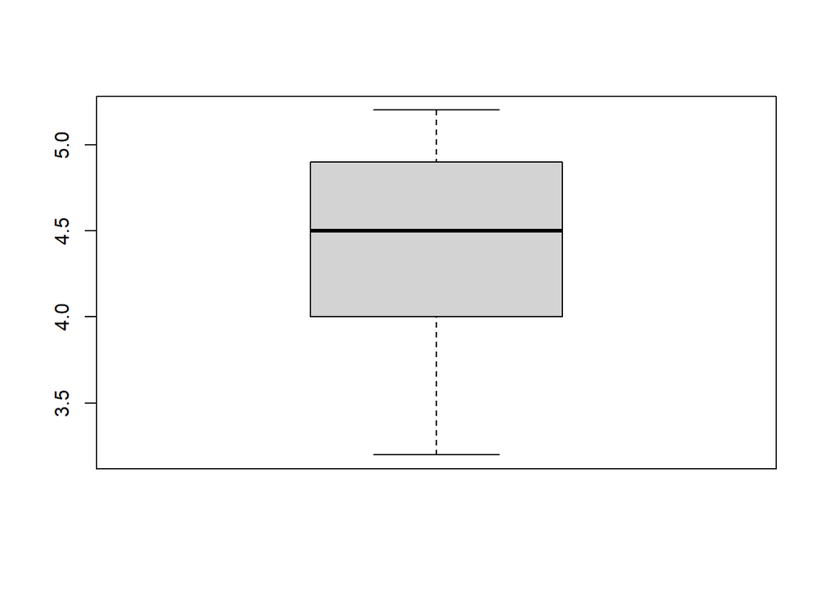

```r
boxplot(dades$Issatop)
```

```r
mean(dades$Issatop)
```

```
## [1] 4.43
```

```r
sd(dades$Issatop)
```

```
## [1] 0.6360468
```

```r
t.test(dades$Issatop)
```

```
##
##  One Sample t-test
##
## data:  dades$Issatop
## t = 22.025, df = 9, p-value = 3.872e-09
## alternative hypothesis: true mean is not equal to 0
## 95 percent confidence interval:
##  3.975 4.885
## sample estimates:
## mean of x
##      4.43
```

L’interval de confiança és (3.975 ; 4,885) amb un 95% de confiança.

Recordem les idees bàsiques d’un interval de confiança

[Simulació intervals](https://www.grbio.eu/statmedia/Statmedia_5/)

# 5 Contrast d’hipòtesi

**Contrast d’hipòtesi**: Tinc una suposició sobre els paràmetres d’una o varies distribucions, per exemple:

- Els valors mitjans de dues poblacions són iguals?

Amb un contrast d’hipòtesis volem verificar si la mostra obtinguda és compatible amb una suposició paramètrica.

# 6 Elements d’un contrast d’hipòtesi

Un contrast estadístic d’hipòtesis és una regla que permet decidir entre dues hipòtesis a partir d’una mostra aleatòria.

- Hipòtesi nul·la: una afirmació feta sobre la població origen de la mostra. Usualment més simple que la seva antagonista. Es designa amb $H_0$.
- Hipòtesi alternativa: també una afirmació de la població origen. Molts cops (NO sempre) és simplement la negació de $H_0$. Es designa amb $H_1$.
  - Bilateral
    $$H_0: \mu=\mu_0$$
    $$H_1: \mu \ne \mu_0$$
  - Unilateral dreta
    $$H_0:
    \mu=\mu_0$$
    $$H_1: \mu >
    \mu_0$$
  - Unilateral esquerra
    $$H_0:
    \mu=\mu_0$$
    $$H_1: \mu <
    \mu_0$$

La regla es basa en la divisió de l’espai mostral en dos subconjunts, un subconjunt de rebuig de H0, la regió crítica $(W)$ i un subconjunt d’acceptació, la regió d’acceptació $(W^c)$.

Generalment la mostra es resumeix en un estadístic de contrast **T** i la regió crítica es construeix basada en aquest estadístic de contrast i la seva distribució.

# 7 Probabilitat d’error

**Sempre** ens podem equivocar quan decidim entre dues hipòtesis en base a una mostra aleatòria.

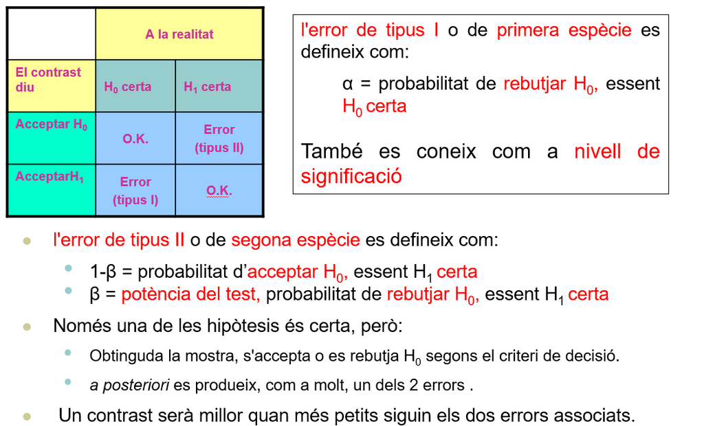

# 8 Relació entre els dos tipus d’error

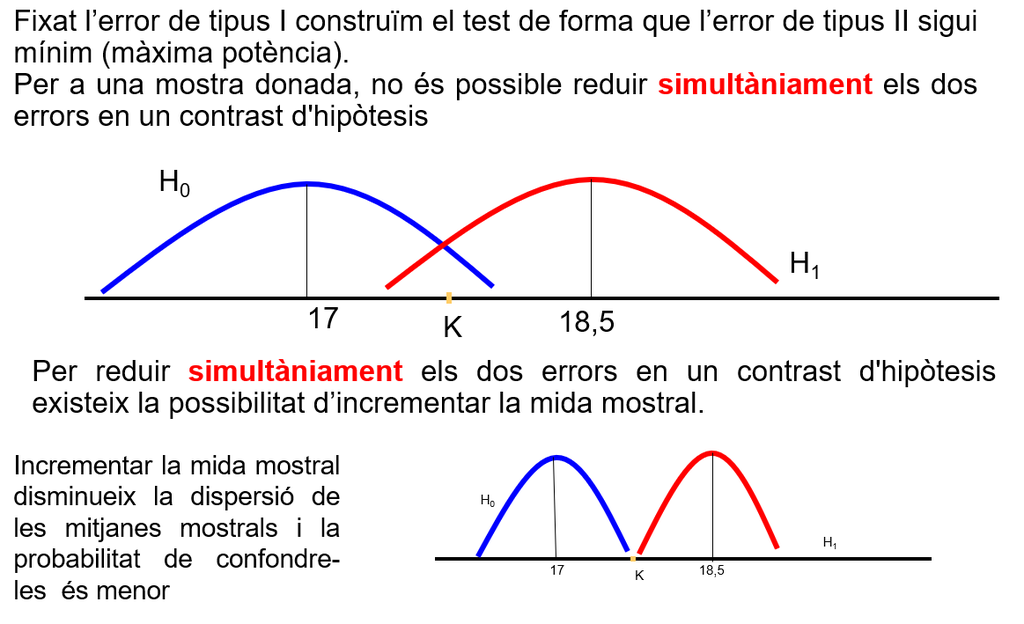

# 9 p-valor

Una forma alternativa de decidir en un contrast és utilitzar el **p-valor**.

Un **p-valor** indica la probabilitat d’obtenir un valor del estadístic de contrast igual o més extrem que el que hem obtingut de la mostra sota la suposició de que $H_0$ és certa. És una forma indirecta de saber si estem dintre o fora de la regió crítica.

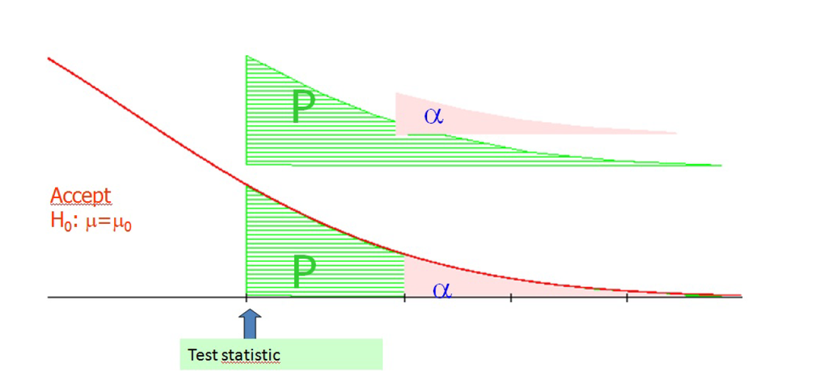

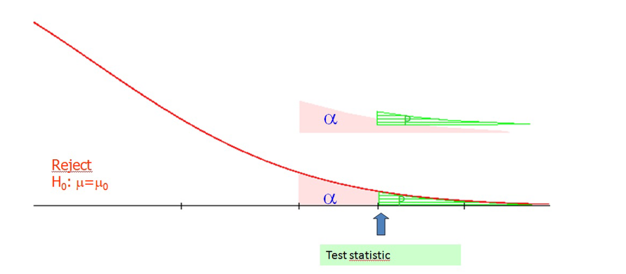

## 9.1 Criteri de decisió amb p-valors

- Rebutjarem $H_0$ quan el p-valor sigui menor que el nivell de significació desitjat, per exemple $\alpha=0.05$.
- Acceptarem $H_0$ quan el p-valor sigui més gran que el nivell de significació desitjat, per exemple $\alpha=0.05$.

# 10 Nivell de significació i p-valor

- $\alpha$ (**nivell de significació**)
  - Fixa’t per endavant per l’investigador
  - Valor petit ( 1 – 5 %)
  - Serveix per concretar la regió crítica
- p-valor
  - Conegut després d’efectuar l’experiment
  - Es defineix com el nivell de significació més petit possible que es pot escollir amb el qual s’accepta la hipòtesis alternativa.
  - És una mesura directa de la versemblança d’obtenir una mostra com l’actual si és certa H0. valors petits indiquen que és molt infreqüent una mostra com l’actual, en canvi valors alts que és freqüent.
  - Serveix per prendre la decisió del test a través de la comparació amb el nivell de significació:

  $$p \le \alpha \Rightarrow \mbox{
  Rebutjem } H_0$$
  $$p > \alpha
  \Rightarrow \mbox{ Acceptem } H_0$$

# 11 Continuació de l’exemple I

## 11.1 Resolució amb format original

**Es pot acceptar, amb nivell de significació del 5%, que el nivell mig de potassi de la població de malalts tractats amb Issatop és inferior al de Oisnet?**

- Assumim que Issatop $\sim N(\mu1,\sigma_1)$ i que Oisnet $\sim N(\mu2,\sigma_2)$ i són dues mostres independents.
- En primer lloc hem de comprovar si les variàncies són iguals

  $$H_0: \sigma_1=\sigma_2$$
  $$H_1: \sigma_1 \ne \sigma_2$$

```r
var.test(dades$Issatop,dades$Oisnet)
```

```
##
##  F test to compare two variances
##
## data:  dades$Issatop and dades$Oisnet
## F = 0.99454, num df = 9, denom df = 9, p-value = 0.9936
## alternative hypothesis: true ratio of variances is not equal to 1
## 95 percent confidence interval:
##  0.2470289 4.0040002
## sample estimates:
## ratio of variances
##           0.994537
```

- I posteriorment fer el test t de Student o test de Welch segons el resultat anterior

$$H_0: \mu_1=\mu_2$$
$$H_1: \mu_1 < \mu_2$$

```r
t.test(dades$Issatop,dades$Oisnet,alternative='l',var.equal = TRUE,paired=FALSE)
```

```
##
##  Two Sample t-test
##
## data:  dades$Issatop and dades$Oisnet
## t = -2.4575, df = 18, p-value = 0.01218
## alternative hypothesis: true difference in means is less than 0
## 95 percent confidence interval:
##        -Inf -0.2060708
## sample estimates:
## mean of x mean of y
##      4.43      5.13
```

Si volem l’interval de confiança bilateral per a la diferència de mitjanes poblacionals

```r
t.test(dades$Issatop,dades$Oisnet,alternative='t',var.equal=TRUE,paired=FALSE)
```

```
##
##  Two Sample t-test
##
## data:  dades$Issatop and dades$Oisnet
## t = -2.4575, df = 18, p-value = 0.02436
## alternative hypothesis: true difference in means is not equal to 0
## 95 percent confidence interval:
##  -1.2984248 -0.1015752
## sample estimates:
## mean of x mean of y
##      4.43      5.13
```

## 11.2 Resolució amb format alternatiu del fitxer de dades

```r
dades2<-read.table('farmac2.csv',header=T,sep=';',dec=',',stringsAsFactors = TRUE)
```

```r
head(dades2)
```

| Potassi | Tractament |
| --- | --- |
| 5.2 | Oisnet |
| 5.7 | Oisnet |
| 4.6 | Oisnet |
| 4.9 | Oisnet |
| 4.7 | Oisnet |
| 6.1 | Oisnet |

```r
summary(dades2)
```

```
##     Potassi        Tractament
##  Min.   :3.200   Issatop:10
##  1st Qu.:4.475   Oisnet :10
##  Median :4.850
##  Mean   :4.780
##  3rd Qu.:5.200
##  Max.   :6.100
```

En aquest cas hem de fer servir una **fórmula** en R.

### 11.2.1 Contrast de variàncies i t de Student

(En aquest cas **no** pot utilitzar-se l’argument **paired** en la crida a t.test)

```r
var.test(Potassi~Tractament,data=dades2)
```

```
##
##  F test to compare two variances
##
## data:  Potassi by Tractament
## F = 0.99454, num df = 9, denom df = 9, p-value = 0.9936
## alternative hypothesis: true ratio of variances is not equal to 1
## 95 percent confidence interval:
##  0.2470289 4.0040002
## sample estimates:
## ratio of variances
##           0.994537
```

```r
t.test(Potassi~Tractament,data=dades2,alternative='l',var.equal=T)
```

```
##
##  Two Sample t-test
##
## data:  Potassi by Tractament
## t = -2.4575, df = 18, p-value = 0.01218
## alternative hypothesis: true difference in means between group Issatop and group Oisnet is less than 0
## 95 percent confidence interval:
##        -Inf -0.2060708
## sample estimates:
## mean in group Issatop  mean in group Oisnet
##                  4.43                  5.13
```

# 12 Exemple amb dades aparellades

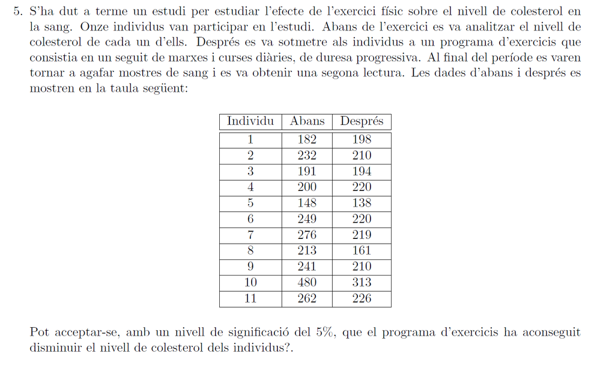

```r
dades3<-read.table('exercici.csv',header=T,sep=';',dec=',',stringsAsFactors = TRUE)
```

$$H_0: \mu_{Abans}=\mu_{Després}$$
$$H_1:
\mu_{Abans}>\mu_{Després}$$

```r
t.test(dades3$abans,dades3$despres,alternative='g',paired=TRUE)
```

```
##
##  Paired t-test
##
## data:  dades3$abans and dades3$despres
## t = 2.1551, df = 10, p-value = 0.02829
## alternative hypothesis: true mean difference is greater than 0
## 95 percent confidence interval:
##  5.275248      Inf
## sample estimates:
## mean difference
##        33.18182
```